# Question

A polynomial, $p(x)$, is given in factored form.
$$p(x)~=~(x+8)\cdot
(x+2)^{2}\cdot (x-5)$$

Which of the following graphs matches $y=p(x)$?

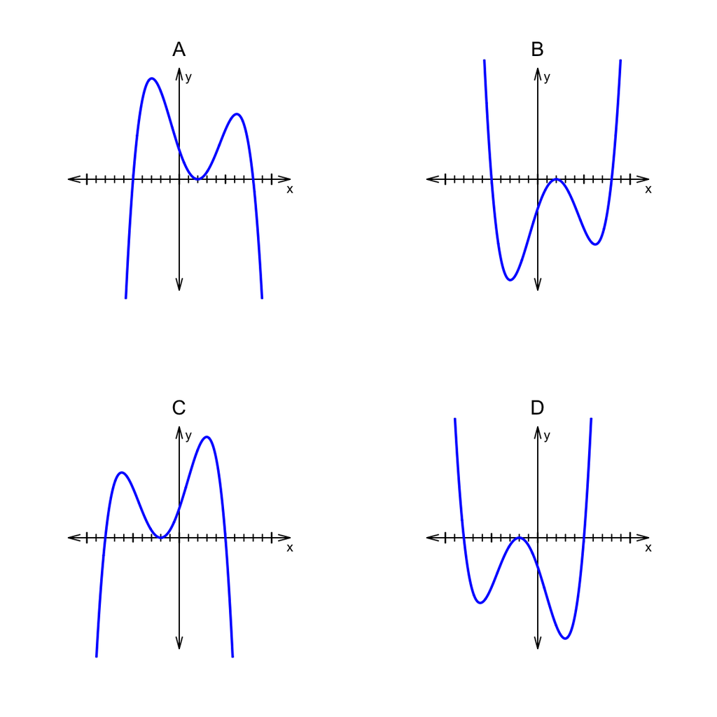

## Answerlist

- A
- B
- C
- D

# Solution

First, consider the end behavior. If you expanded the polynomial into standard form, the highest-degree term would be $x^{4}$.

$$p(x)~=~x^{4}+\ldots$$

The highest degree term has a positive coefficient and an even degree, so the end behavior is **“up,up”**. Or, more formally, $\lim\limits_{x\to-\infty} p(x) ~=~ \infty$ and $\lim\limits_{x\to\infty} p(x) ~=~ \infty$.

Next, we consider the roots. From the factored form, $p(x)~=~(x+8)\cdot (x+2)^{2}\cdot (x-5)$, it is easy to see (see [zero-product property](https://en.wikipedia.org/wiki/Zero-product_property)) that $x=-8$ or $x=-2$ or $x=5$ makes the polynomial output 0.

$$p(-8)~=~(-8+8)\cdot (-8+2)^{2}\cdot
(-8-5)~=~0$$
$$p(-2)~=~(-2+8)\cdot
(-2+2)^{2}\cdot (-2-5)~=~0$$
$$p(5)~=~(5+8)\cdot (5+2)^{2}\cdot
(5-5)~=~0$$

We predict that at $x=-2$ there is a double root (multiplicity of 2) because the corresponding factor is squared. Graphically, we expect the curve to “bounce” off the $x$ axis at $x=-2$. At the other roots, we expect the curve to cut through the $x$ axis.

Anyway, based on this analysis, we can produce a [sign](https://en.wikipedia.org/wiki/Sign_function) graph of the polynomial.

| $x$ interval or value | sign analysis of $p(x)~=~(x+8)\cdot (x+2)^{2}\cdot (x-5)$ | sign |
| --- | --- | --- |
| $(-\infty,-8)$ | $(\mathrm{neg})\cdot (\mathrm{neg})^{2}\cdot (\mathrm{neg})$ | $1$ |
| $-8$ | $(\mathrm{zero})\cdot (\mathrm{neg})^{2}\cdot (\mathrm{neg})$ | $0$ |
| $(-8,-2)$ | $(\mathrm{pos})\cdot (\mathrm{neg})^{2}\cdot (\mathrm{neg})$ | $-1$ |
| $-2$ | $(\mathrm{pos})\cdot (\mathrm{zero})^{2}\cdot (\mathrm{neg})$ | $0$ |
| $(-2,5)$ | $(\mathrm{pos})\cdot (\mathrm{pos})^{2}\cdot (\mathrm{neg})$ | $-1$ |
| $5$ | $(\mathrm{pos})\cdot (\mathrm{pos})^{2}\cdot (\mathrm{zero})$ | $0$ |
| $(5,\infty)$ | $(\mathrm{pos})\cdot (\mathrm{pos})^{2}\cdot (\mathrm{pos})$ | $1$ |

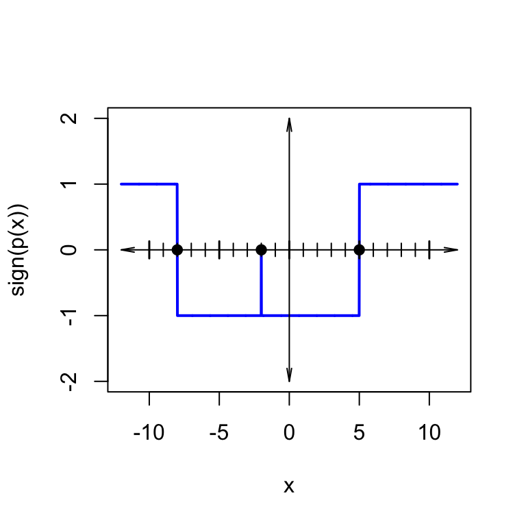

And only one option matches.

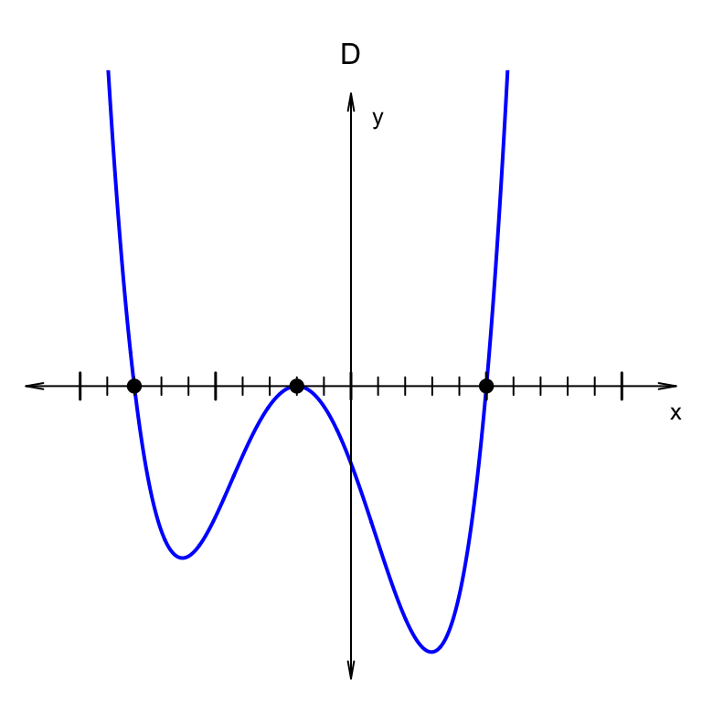

# Meta-information

extype: schoice exsolution: 0001 exname: sketch_factored_poly